# flextools Optimization — Full Benchmark

2026-08-13

This reports presents a comprehensive benchmark of the `flextools` demand and battery optimization functions, sweeping across key parameters to illustrate their impact on performance and outcomes.

# 0 · Data & baselines

The simulations in this report use the `energy_profiles` dataset included in the package, which contains 15-minute data for a full year (2023) of solar production, load, and time-varying prices.  
The demand and battery optimization functions take this raw data and construct the necessary input tables for the solvers; these are shown in the next two sections. The battery parameters are set to `capacity = 50` kWh and `power = 4` kW (for both charge and discharge) for all simulations in this report.

```r
library(lubridate)

# ── Source datasets ────────────────────────────────────────────────────────────
# energy_profiles: full year 2023, 15-min resolution (35 040 rows)
profiles_week <- flextools::energy_profiles |>
  filter(isoweek(datetime) == 18)   # one representative week (672 rows)

profiles_year <- flextools::energy_profiles   # full year (35 040 rows)

# ── Demand optimization datasets ───────────────────────────────────────────────
# price_exported is set to price_imported - 0.05 so it is always lower
opt_demand_week <- demand_opt_data(profiles_week) |>
  mutate(price_exported = price_imported - 0.05)
opt_demand_year <- demand_opt_data(profiles_year) |>
  mutate(price_exported = price_imported - 0.05)

# ── Battery optimization datasets ─────────────────────────────────────────────
opt_battery_week <- battery_opt_data(profiles_week) |>
  mutate(price_exported = price_imported - 0.05)
opt_battery_year <- battery_opt_data(profiles_year) |>
  mutate(price_exported = price_imported - 0.05)

# ── Baselines (no optimization) ────────────────────────────────────────────────
base_demand  <- demand_baseline(opt_demand_week)
base_battery <- battery_baseline(opt_battery_week)

# Average import price — used as a λ reference in both demand and battery sections
avg_import_price <- mean(opt_demand_week$price_imported)
```

## Demand dataset

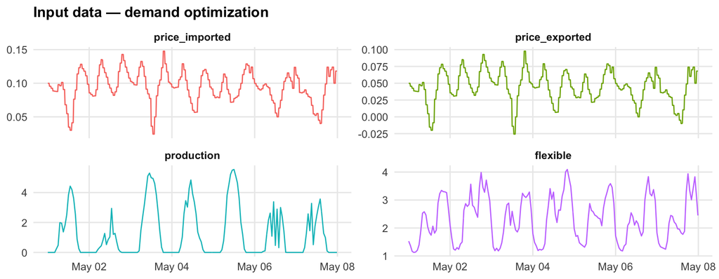

```r
opt_demand_week |>
  tidyr::pivot_longer(-datetime, names_to = "variable") |>
  dplyr::filter(variable %in% c("price_imported", "price_exported",
                                 "production", "flexible")) |>
  dplyr::mutate(variable = factor(variable,
    levels = c("price_imported", "price_exported", "production", "flexible"))) |>
  ggplot(aes(datetime, value, colour = variable)) +
  geom_line(linewidth = 0.5) +
  facet_wrap(~ variable, scales = "free_y", ncol = 2) +
  labs(title = "Input data — demand optimization",
       x = NULL, y = NULL, colour = NULL) +
  theme_bench() +
  theme(legend.position = "none")
```

## Battery dataset

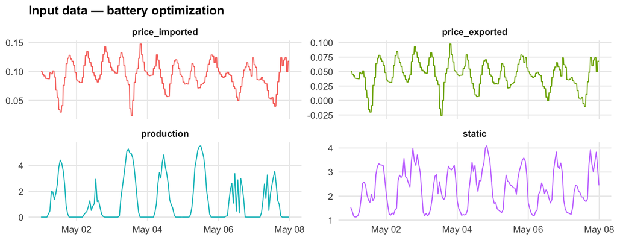

```r
opt_battery_week |>
  tidyr::pivot_longer(-datetime, names_to = "variable") |>
  dplyr::filter(variable %in% c("price_imported", "price_exported",
                                 "production", "static")) |>
  dplyr::mutate(variable = factor(variable,
    levels = c("price_imported", "price_exported", "production", "static"))) |>
  ggplot(aes(datetime, value, colour = variable)) +
  geom_line(linewidth = 0.5) +
  facet_wrap(~ variable, scales = "free_y", ncol = 2) +
  labs(title = "Input data — battery optimization",
       x = NULL, y = NULL, colour = NULL) +
  theme_bench() +
  theme(legend.position = "none")
```

**Baseline KPIs**

```r
tibble::tibble(
  Metric          = c("Cost (€)", "Peak from grid (kW)", "Peak to grid (kW)"),
  `Demand (no opt)` = c(
    round(base_demand$cost, 2),
    round(base_demand$peak_from_grid, 2),
    round(base_demand$peak_to_grid, 2)
  ),
  `Battery (no battery)` = c(
    round(base_battery$cost, 2),
    round(base_battery$peak_from_grid, 2),
    round(base_battery$peak_to_grid, 2)
  )
) |> knitr::kable()
```

| Metric | Demand (no opt) | Battery (no battery) |
| --- | --- | --- |
| Cost (€) | 100.09 | 100.09 |
| Peak from grid (kW) | 4.09 | 4.09 |
| Peak to grid (kW) | 3.20 | 3.20 |

# 1 · Demand optimization

The `optimize_demand()` function shifts flexible load in time to meet one of three goals:

| `opt_objective` | Solver | Description |
| --- | --- | --- |
| `"grid"` / `w = 1` | QP | Minimise squared net power exchanged with the grid |
| `"capacity"` | QP | Minimise squared net power that exceeds grid capacity |
| `"cost"` / `w = 0` | MILP | Minimise energy cost (import/export prices) |
| `w ∈ (0, 1)` | MIQP | Weighted combination of both |

**Key parameters:**

- **`w`** — blending weight; `w = 1` is pure grid, `w = 0` is pure cost.
- **`lambda`** — penalty on load *changes* between slots. Larger values produce smoother profiles but may sacrifice objective quality.

## 1.1 · Tradeoff curve: peak reduction vs. energy cost

```r
sweep_d_w <- sweep_demand(
  opt_demand_week,
  w_seq      = W_SEQ_FINE,
  lambda_seq = 0
)
```

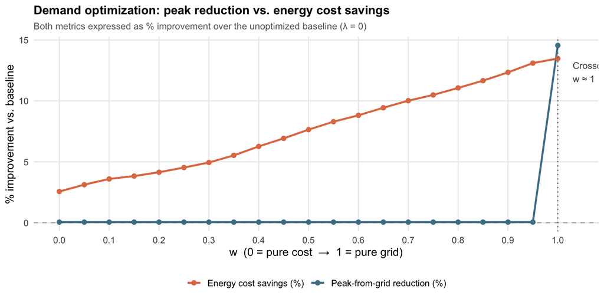

```r
# Express both KPIs as % improvement relative to baseline (positive = better)
tradeoff_d <- sweep_d_w |>
  mutate(
    peak_reduction_pct = (base_demand$peak_from_grid - peak_from_grid) /
                          base_demand$peak_from_grid * 100,
    cost_savings_pct   = (base_demand$cost - cost) /
                          abs(base_demand$cost) * 100
  ) |>
  tidyr::pivot_longer(
    c(peak_reduction_pct, cost_savings_pct),
    names_to  = "metric",
    values_to = "pct_improvement"
  ) |>
  mutate(metric = recode(metric,
    peak_reduction_pct = "Peak-from-grid reduction (%)",
    cost_savings_pct   = "Energy cost savings (%)"
  ))

# Find crossover (where the two curves are closest to equal)
crossover_d <- sweep_d_w |>
  mutate(
    peak_red  = (base_demand$peak_from_grid - peak_from_grid) /
                 base_demand$peak_from_grid * 100,
    cost_sav  = (base_demand$cost - cost) / abs(base_demand$cost) * 100,
    diff_abs  = abs(peak_red - cost_sav)
  ) |>
  slice_min(diff_abs, n = 1)

ggplot(tradeoff_d, aes(w, pct_improvement, colour = metric)) +
  geom_hline(yintercept = 0, linetype = "dashed", colour = "grey70") +
  geom_line(linewidth = 1) +
  geom_point(size = 2) +
  geom_vline(
    xintercept = crossover_d$w,
    linetype = "dotted", colour = "grey40"
  ) +
  annotate("text",
    x     = crossover_d$w + 0.03,
    y     = max(tradeoff_d$pct_improvement) * 0.85,
    label = paste0("Crossover\nw ≈ ", crossover_d$w),
    size  = 3.5, colour = "grey30", hjust = 0
  ) +
  scale_x_continuous(breaks = seq(0, 1, 0.1)) +
  scale_colour_manual(values = c("#E07B54", "#4E8098")) +
  labs(
    title    = "Demand optimization: peak reduction vs. energy cost savings",
    subtitle = "Both metrics expressed as % improvement over the unoptimized baseline (λ = 0)",
    x        = "w  (0 = pure cost  →  1 = pure grid)",
    y        = "% improvement vs. baseline",
    colour   = NULL
  ) +
  theme_bench()
```

> **Note on the cost metric:** `evaluate_cost()` measures only grid energy costs (import price × kWh imported − export price × kWh exported). The `"cost"` optimization objective *also* includes balancing-market revenues (`price_turn_up` / `price_turn_down`), so the grid-energy-cost savings shown here may *understate* the true economic benefit of `w = 0`. **Conversely, `w = 1` (grid) often shows good grid-cost savings as a side effect of aligning demand with local solar production.**

## 1.2 · Lambda vs. energy savings

```r
sweep_d_lam <- sweep_demand(
  opt_demand_week,
  w_seq      = W_SEQ_COARSE,
  lambda_seq = LAMBDA_SEQ
)
```

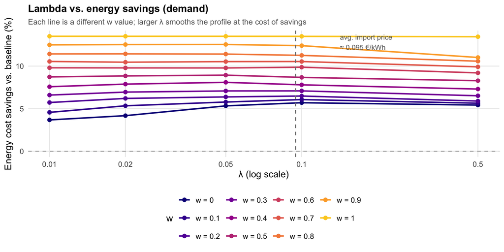

```r
max_savings_d <- sweep_d_lam |>
  filter(lambda > 0) |>
  mutate(s = (base_demand$cost - cost) / abs(base_demand$cost) * 100) |>
  pull(s) |> max(na.rm = TRUE)

sweep_d_lam |>
  filter(lambda > 0) |>
  mutate(
    cost_savings_pct = (base_demand$cost - cost) /
                        abs(base_demand$cost) * 100,
    w_lab = paste0("w = ", w)
  ) |>
  ggplot(aes(lambda, cost_savings_pct, colour = w_lab, group = w_lab)) +
  geom_hline(yintercept = 0, linetype = "dashed", colour = "grey70") +
  geom_line(linewidth = 0.9) +
  geom_point(size = 2) +
  geom_vline(
    xintercept = avg_import_price,
    linetype = "dashed", colour = "grey50"
  ) +
  annotate("text",
    x     = avg_import_price * 1.5,
    y     = max_savings_d * 0.95,
    label = paste0("avg. import price\n≈ ", round(avg_import_price, 3), " €/kWh"),
    size  = 3.2, colour = "grey40", hjust = 0
  ) +
  scale_x_log10(
    breaks = LAMBDA_SEQ[LAMBDA_SEQ > 0],
    labels = as.character(LAMBDA_SEQ[LAMBDA_SEQ > 0])
  ) +
  scale_colour_viridis_d(option = "plasma", end = 0.9) +
  labs(
    title    = "Lambda vs. energy savings (demand)",
    subtitle = "Each line is a different w value; larger λ smooths the profile at the cost of savings",
    x        = "λ (log scale)",
    y        = "Energy cost savings vs. baseline (%)",
    colour   = "w"
  ) +
  theme_bench()
```

> A practical starting reference for `lambda` is the **average import price** (≈ 0.095 €/kWh in this dataset): at this value, the ramp penalty is comparable in magnitude to the energy price, providing meaningful smoothing without collapsing savings. **Recommended range: λ ≈ average import price to 2× average import price.**

# 2 · Battery optimization

The `add_battery_optimization()` function schedules battery charge/discharge to minimise a weighted objective (cost, grid, or combined):

| `opt_objective` | Solver | Description |
| --- | --- | --- |
| `"grid"` / `w = 1` | QP | Minimise squared net power exchanged with the grid |
| `"capacity"` | QP | Minimise squared net power that exceeds grid capacity |
| `"cost"` / `w = 0` | MILP or LP (if cycle_cost > 0) | Minimise energy cost (import/export prices) |
| `w ∈ (0, 1)` | QP | Weighted combination of both |

**Key parameters:**

Key parameters are the same `w` and `lambda` as for demand, plus:

- **`cycle_cost`** (€/kWh cycled) — explicit degradation penalty added to the cost objective. Setting a non-zero value converts the MILP to a pure LP (much faster) and directly limits cycling.
- **`charge_eff` / `discharge_eff`** — round-trip efficiency losses; when η < 1 the battery internalises losses in the SOC constraints, which also indirectly reduces cycling.

## 2.1 · Tradeoff curve: peak reduction vs. energy cost

```r
sweep_b_tradeoff <- sweep_battery(
  opt_battery_week,
  w_seq      = W_SEQ_FINE,
  lambda_seq = 0,
  eff_seq    = 1,
  Bcap = BCAP, Bc = BC, Bd = BD
)
```

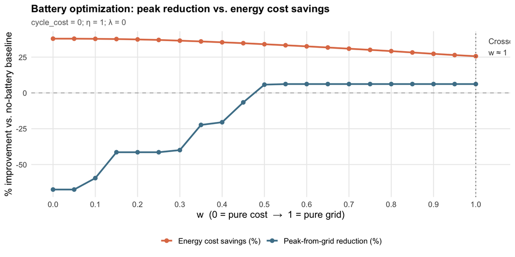

```r
tradeoff_b <- sweep_b_tradeoff |>
  mutate(
    peak_reduction_pct = (base_battery$peak_from_grid - peak_from_grid) /
                          base_battery$peak_from_grid * 100,
    cost_savings_pct   = (base_battery$cost - cost) /
                          abs(base_battery$cost) * 100
  ) |>
  tidyr::pivot_longer(
    c(peak_reduction_pct, cost_savings_pct),
    names_to  = "metric",
    values_to = "pct_improvement"
  ) |>
  mutate(metric = recode(metric,
    peak_reduction_pct = "Peak-from-grid reduction (%)",
    cost_savings_pct   = "Energy cost savings (%)"
  ))

crossover_b <- sweep_b_tradeoff |>
  mutate(
    peak_red  = (base_battery$peak_from_grid - peak_from_grid) /
                 base_battery$peak_from_grid * 100,
    cost_sav  = (base_battery$cost - cost) / abs(base_battery$cost) * 100,
    diff_abs  = abs(peak_red - cost_sav)
  ) |>
  slice_min(diff_abs, n = 1)

ggplot(tradeoff_b, aes(w, pct_improvement, colour = metric)) +
  geom_hline(yintercept = 0, linetype = "dashed", colour = "grey70") +
  geom_line(linewidth = 1) +
  geom_point(size = 2) +
  geom_vline(
    xintercept = crossover_b$w,
    linetype = "dotted", colour = "grey40"
  ) +
  annotate("text",
    x     = crossover_b$w + 0.03,
    y     = max(tradeoff_b$pct_improvement) * 0.85,
    label = paste0("Crossover\nw ≈ ", crossover_b$w),
    size  = 3.5, colour = "grey30", hjust = 0
  ) +
  scale_x_continuous(breaks = seq(0, 1, 0.1)) +
  scale_colour_manual(values = c("#E07B54", "#4E8098")) +
  labs(
    title    = "Battery optimization: peak reduction vs. energy cost savings",
    subtitle = "cycle_cost = 0; η = 1; λ = 0",
    x        = "w  (0 = pure cost  →  1 = pure grid)",
    y        = "% improvement vs. no-battery baseline",
    colour   = NULL
  ) +
  theme_bench()
```

The chart confirms that `w = 0` (cost) maximises energy savings through price-arbitrage, while `w = 1` (grid) focuses entirely on peak reduction, often at the cost of energy savings. If the primary goal is to reduce the electricity bill, choose `w = 0` (or a low `w`); if the priority is grid relief, choose `w` near 1.

## 2.2 · Cycle count

```r
sweep_b_eff <- sweep_battery(
  opt_battery_week,
  w_seq      = W_SEQ_COARSE,
  lambda_seq = 0,
  eff_seq    = EFF_SEQ,
  Bcap = BCAP, Bc = BC, Bd = BD
)
```

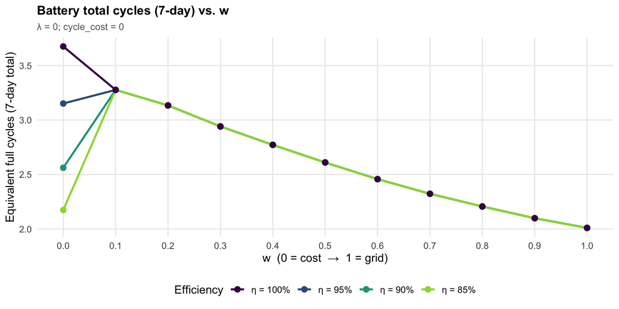

```r
# Order efficiency legend from highest (100%) to lowest (85%)
eff_levels <- paste0("η = ", scales::percent(rev(EFF_SEQ), accuracy = 1))

sweep_b_eff |>
  mutate(eff_lab = factor(
    paste0("η = ", scales::percent(eff, accuracy = 1)),
    levels = eff_levels
  )) |>
  ggplot(aes(w, n_cycles, colour = eff_lab, group = eff_lab)) +
  geom_line(linewidth = 1) +
  geom_point(size = 2.5) +
  scale_x_continuous(breaks = seq(0, 1, 0.1)) +
  scale_colour_viridis_d(option = "viridis", end = 0.85) +
  labs(
    title    = "Battery total cycles (7-day) vs. w",
    subtitle = "λ = 0; cycle_cost = 0",
    x        = "w  (0 = cost  →  1 = grid)",
    y        = "Equivalent full cycles (7-day total)",
    colour   = "Efficiency"
  ) +
  theme_bench()
```

**Key insight:** `efficiency` and `cycle_cost` are parameters that influence the battery profile **only through the cost objective** (`w = 0`). For the cost objective, round-trip losses make each charge/discharge cycle less profitable, so the optimizer naturally reduces cycling. For the grid and combined objectives, neither `efficiency` nor `cycle_cost` enters the objective function. Any reduction in cycles visible for `w = 1` or intermediate `w` values as efficiency drops is simply a side effect of the changed SOC constraints (less energy is stored and delivered per cycle), not a deliberate optimization decision — the battery profile is less aggressive only because the constraints force it, not because the optimizer is trying to save money.

For practical control of cycling, `cycle_cost` should always be paired with the **cost objective**. Using the combined or grid objective and hoping that efficiency limits the cycles is not a reliable strategy.

The reduction in cycles for the cost objective with lower efficiency is beneficial from a lifetime perspective, but it comes at a price: a less efficient battery extracts less value from arbitrage. The next section quantifies this cost in terms of energy savings.

```r
# Battery profiles for each efficiency (cost obj., λ = 0, cycle_cost = 0)
profiles_eff_ts <- opt_battery_week |> select(datetime)
for (e in EFF_SEQ) {
  res <- bench_battery(
    opt_battery_week,
    opt_objective = "cost",
    lambda        = 0,
    charge_eff    = e,
    discharge_eff = e,
    cycle_cost    = 0,
    Bcap = BCAP, Bc = BC, Bd = BD
  )
  profiles_eff_ts[[paste0("η = ", scales::percent(e, accuracy = 1))]] <- res$profile
}

profiles_eff_ts |>
  timefully::plot_ts(
    title        = "Battery profiles by efficiency  (cost obj., λ = 0, cycle_cost = 0)",
    ylab         = "Battery power (kW)",
    legend_width = 120
  )
```

[interactive chart not shown]

```r
# Focus on cost objective (w=0), η=90% — lambda varies, cycle_cost = 0
sweep_b_cost_opt_lam <- sweep_battery(
  opt_battery_week,
  w_seq      = 0,
  lambda_seq = LAMBDA_SEQ,
  eff_seq    = 0.90,
  Bcap = BCAP, Bc = BC, Bd = BD
)

# Anchored sweep: lambda varies, cycle_cost = 0.02, η=90%
sweep_b_cost_opt_lam_cc02 <- sweep_battery(
  opt_battery_week,
  w_seq      = 0,
  lambda_seq = LAMBDA_SEQ,
  eff_seq    = 0.90,
  cycle_cost = 0.02,
  Bcap = BCAP, Bc = BC, Bd = BD
)

# cycle_cost × efficiency sweep: all EFF_SEQ values, lambda = 0, w = 0
sweep_b_cc_eff <- purrr::map(EFF_SEQ, function(e) {
  sweep_battery_cc(
    opt_battery_week,
    w_seq          = 0,
    cycle_cost_seq = CYCLE_COST_SEQ,
    charge_eff     = e,
    discharge_eff  = e,
    Bcap = BCAP, Bc = BC, Bd = BD
  ) |> mutate(eff = e)
}) |> purrr::list_rbind()
```

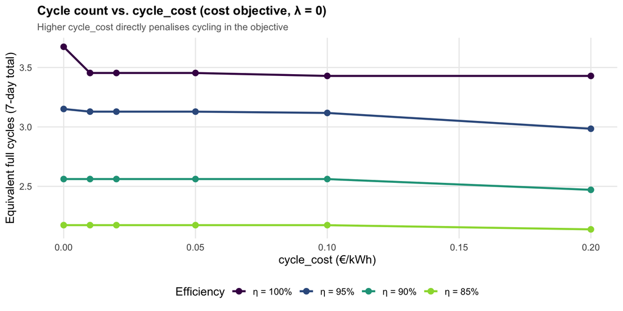

```r
sweep_b_cc_eff |>
  mutate(eff_lab = factor(
    paste0("η = ", scales::percent(eff, accuracy = 1)),
    levels = paste0("η = ", scales::percent(rev(EFF_SEQ), accuracy = 1))
  )) |>
  ggplot(aes(cycle_cost, n_cycles, colour = eff_lab, group = eff_lab)) +
  geom_line(linewidth = 1) +
  geom_point(size = 2.5) +
  scale_colour_viridis_d(option = "viridis", end = 0.85) +
  labs(
    title    = "Cycle count vs. cycle_cost (cost objective, λ = 0)",
    subtitle = "Higher cycle_cost directly penalises cycling in the objective",
    x        = "cycle_cost (€/kWh)",
    y        = "Equivalent full cycles (7-day total)",
    colour   = "Efficiency"
  ) +
  theme_bench()
```

Note that the cycle count barely decreases with `cycle_cost` until values around 0.20 €/kWh — which likely exceeds the real battery degradation cost in most deployments (typical Li-ion values are 0.02 – 0.05 €/kWh). This means `cycle_cost` alone is not very effective at reducing cycles unless set unrealistically high. Its main benefit is the solver speedup it provides (see Section 3).

```r
# Battery profiles for each cycle_cost (cost obj., η = 90%, λ = 0)
profiles_cc_ts <- opt_battery_week |> select(datetime)
for (cc in CYCLE_COST_SEQ) {
  res <- bench_battery(
    opt_battery_week,
    opt_objective = "cost",
    lambda        = 0,
    charge_eff    = 0.90,
    discharge_eff = 0.90,
    cycle_cost    = cc,
    Bcap = BCAP, Bc = BC, Bd = BD
  )
  profiles_cc_ts[[paste0("cc = ", cc)]] <- res$profile
}

profiles_cc_ts |>
  timefully::plot_ts(
    title        = "Battery profiles by cycle_cost  (cost obj., η = 90%, λ = 0)",
    ylab         = "Battery power (kW)",
    legend_width = 120
  )
```

[interactive chart not shown]

```r
# Full parameter-space sweep (w × lambda × eff × cycle_cost) on the week dataset
# Used by the overview bar charts at the end of sections 2.2 and 2.3
obj_seq <- c("cost", "0.1", "0.5", "grid")
sweep_b_overview <- purrr::map(c(0, 0.1), function(lam) {
  purrr::map(obj_seq, function(obj_chr) {
    purrr::map(c(1.0, 0.90), function(eff_val) {
      purrr::map(c(0, 0.02), function(cc_val) {
        obj <- if (obj_chr %in% c("grid", "cost")) obj_chr else as.numeric(obj_chr)
        res <- bench_battery(
          opt_battery_week,
          opt_objective = obj,
          lambda        = lam,
          charge_eff    = eff_val,
          discharge_eff = eff_val,
          cycle_cost    = cc_val,
          Bcap = BCAP, Bc = BC, Bd = BD
        )
        tibble::tibble(
          objective  = obj_chr,
          lambda     = lam,
          eff        = eff_val,
          cycle_cost = cc_val,
          n_cycles   = res$n_cycles,
          cost       = res$cost
        )
      }) |> purrr::list_rbind()
    }) |> purrr::list_rbind()
  }) |> purrr::list_rbind()
}) |> purrr::list_rbind()
```

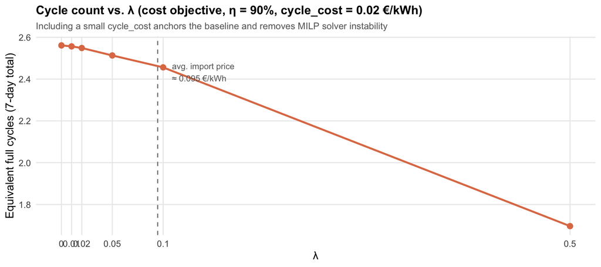

```r
sweep_b_cost_opt_lam_cc02 |>
  ggplot(aes(lambda, n_cycles)) +
  geom_line(linewidth = 1, colour = "#E07B54") +
  geom_point(size = 2.5, colour = "#E07B54") +
  geom_vline(
    xintercept = avg_import_price,
    linetype = "dashed", colour = "grey50"
  ) +
  annotate("text",
    x     = avg_import_price * 1.15,
    y     = max(sweep_b_cost_opt_lam_cc02$n_cycles) * 0.95,
    label = paste0("avg. import price\n≈ ", round(avg_import_price, 3), " €/kWh"),
    size  = 3.2, colour = "grey40", hjust = 0
  ) +
  scale_x_continuous(
    breaks = LAMBDA_SEQ,
    labels = as.character(LAMBDA_SEQ)
  ) +
  labs(
    title    = "Cycle count vs. λ (cost objective, η = 90%, cycle_cost = 0.02 €/kWh)",
    subtitle = "Including a small cycle_cost anchors the baseline and removes MILP solver instability",
    x        = "λ",
    y        = "Equivalent full cycles (7-day total)"
  ) +
  theme_bench()
```

With `cycle_cost = 0.02` included (to anchor the solver in LP mode), the relationship between `lambda` and cycle count is cleaner and monotonic. Larger `lambda` consistently reduces cycles by penalising rapid charge/discharge transitions.

```r
# Collect battery power profiles for each lambda (same settings as sweep above)
profiles_lam_ts <- opt_battery_week |> select(datetime)
for (lam in LAMBDA_SEQ) {
  res <- bench_battery(
    opt_battery_week,
    opt_objective = "cost",
    lambda        = lam,
    charge_eff    = 0.90,
    discharge_eff = 0.90,
    cycle_cost    = 0.02,
    Bcap = BCAP, Bc = BC, Bd = BD
  )
  profiles_lam_ts[[paste0("λ = ", lam)]] <- res$profile
}

profiles_lam_ts |>
  timefully::plot_ts(
    title        = "Battery profiles by λ  (cost obj., η = 90%, cycle_cost = 0.02 €/kWh)",
    ylab         = "Battery power (kW)",
    legend_width = 120
  )
```

[interactive chart not shown]

The average import price (≈ 0.095 €/kWh in this dataset) provides an intuitive reference for setting `lambda`: at this value, the smoothing penalty on a 1 kW ramp per time slot is comparable in magnitude to the energy cost of importing 1 kWh. Values of `lambda` well below the average import price have limited effect on cycling; values at or above it produce meaningful smoothing. **Recommended range: λ ≈ average import price to 2× average import price** — this smooths the profile noticeably while retaining most of the energy savings.

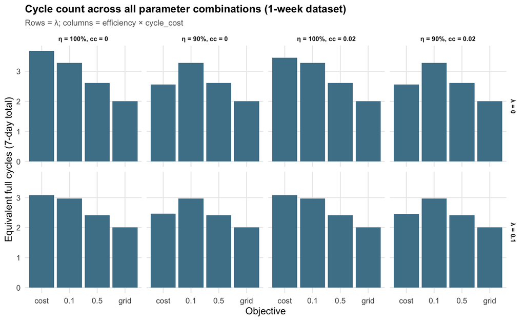

```r
sweep_b_overview |>
  mutate(
    lambda_lab = paste0("λ = ", lambda),
    objective  = factor(objective, levels = c("cost", "0.1", "0.5", "grid")),
    eff_cc_lab = paste0(
      ifelse(eff == 1.0, "η = 100%", "η = 90%"),
      ", cc = ", cycle_cost
    ),
    eff_cc_lab = factor(eff_cc_lab, levels = c(
      "η = 100%, cc = 0", "η = 90%, cc = 0",
      "η = 100%, cc = 0.02", "η = 90%, cc = 0.02"
    ))
  ) |>
  ggplot(aes(objective, n_cycles)) +
  geom_col(fill = "#4E8098") +
  facet_grid(lambda_lab ~ eff_cc_lab, scales = "fixed") +
  labs(
    title    = "Cycle count across all parameter combinations (1-week dataset)",
    subtitle = "Rows = λ; columns = efficiency × cycle_cost",
    x        = "Objective",
    y        = "Equivalent full cycles (7-day total)"
  ) +
  theme_bench() +
  theme(strip.text = element_text(size = 8))
```

## 2.3 · Energy savings

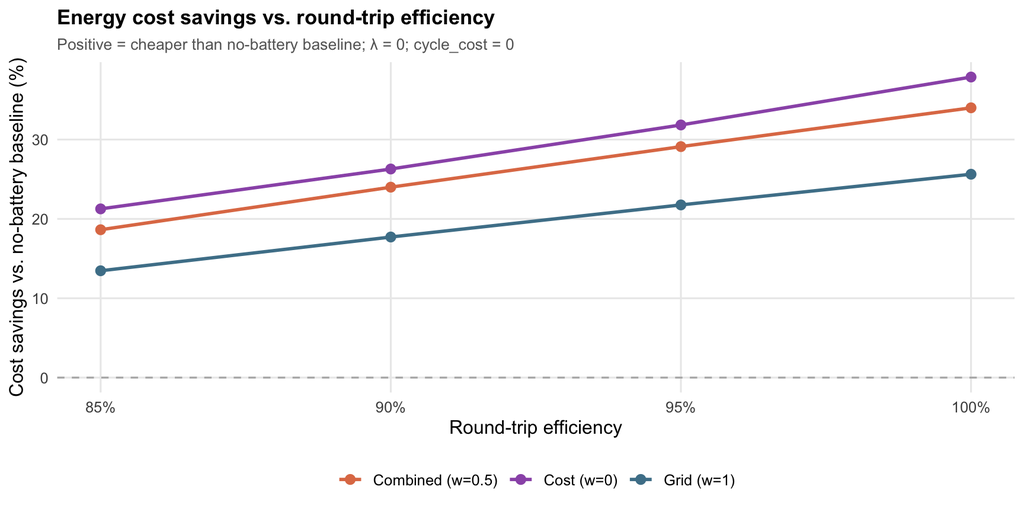

```r
sweep_b_eff |>
  filter(w %in% c(0, 0.5, 1)) |>
  mutate(
    cost_savings_pct = (base_battery$cost - cost) /
                        abs(base_battery$cost) * 100,
    objective = w_label(w)
  ) |>
  ggplot(aes(eff, cost_savings_pct, colour = objective, group = objective)) +
  geom_hline(yintercept = 0, linetype = "dashed", colour = "grey70") +
  geom_line(linewidth = 1) +
  geom_point(size = 2.5) +
  scale_x_continuous(
    breaks = EFF_SEQ,
    labels = scales::percent_format(accuracy = 1)
  ) +
  scale_colour_manual(values = c("#E07B54", "#9B59B6", "#4E8098")) +
  labs(
    title    = "Energy cost savings vs. round-trip efficiency",
    subtitle = "Positive = cheaper than no-battery baseline; λ = 0; cycle_cost = 0",
    x        = "Round-trip efficiency",
    y        = "Cost savings vs. no-battery baseline (%)",
    colour   = NULL
  ) +
  theme_bench()
```

Round-trip efficiency losses are now included in the cost evaluation: charging draws `B / charge_eff` from the grid (more than stored), and discharging delivers only `B × discharge_eff` back (less than released from the SOC). This means the savings shown already reflect the full energy cost of operating the battery at a given efficiency.

For the **cost objective**, lower efficiency directly erodes arbitrage profits — the battery draws more from the grid when charging and delivers less when discharging, so the energy-cost saving shrinks as η falls. For the **grid objective**, efficiency does not enter the objective function, so the optimizer cycles regardless; the savings change stems entirely from the extra grid energy drawn to compensate for losses, not from a deliberate change in strategy.

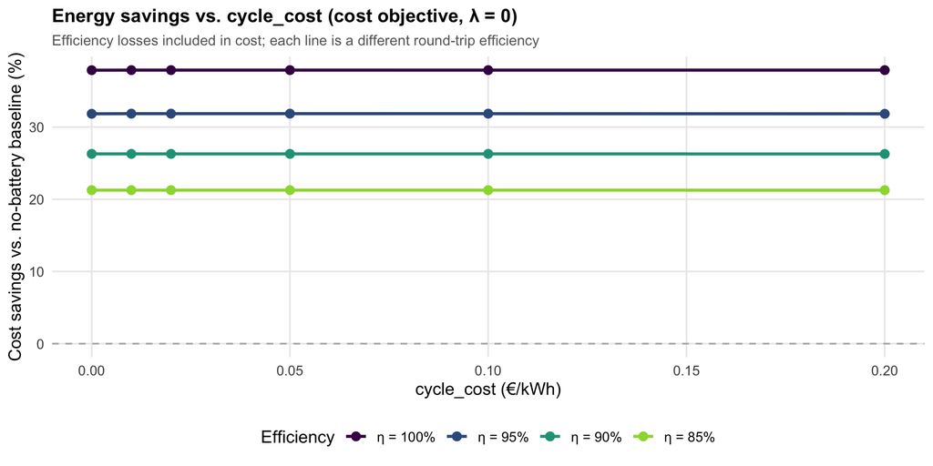

```r
sweep_b_cc_eff |>
  mutate(
    cost_savings_pct = (base_battery$cost - cost) /
                        abs(base_battery$cost) * 100,
    eff_lab = factor(
      paste0("η = ", scales::percent(eff, accuracy = 1)),
      levels = paste0("η = ", scales::percent(rev(EFF_SEQ), accuracy = 1))
    )
  ) |>
  ggplot(aes(cycle_cost, cost_savings_pct, colour = eff_lab, group = eff_lab)) +
  geom_hline(yintercept = 0, linetype = "dashed", colour = "grey70") +
  geom_line(linewidth = 1) +
  geom_point(size = 2.5) +
  scale_colour_viridis_d(option = "viridis", end = 0.85) +
  labs(
    title    = "Energy savings vs. cycle_cost (cost objective, λ = 0)",
    subtitle = "Efficiency losses included in cost; each line is a different round-trip efficiency",
    x        = "cycle_cost (€/kWh)",
    y        = "Cost savings vs. no-battery baseline (%)",
    colour   = "Efficiency"
  ) +
  theme_bench()
```

With efficiency losses now included in the cost evaluation, each line shows the true energy savings at a given efficiency — no manual adjustment is needed. Higher efficiency consistently yields better savings because charging losses are smaller. `cycle_cost` has little effect on the energy savings themselves (the lines are nearly flat), which confirms that its main role is to limit cycling and speed up the solver rather than improve economic performance.

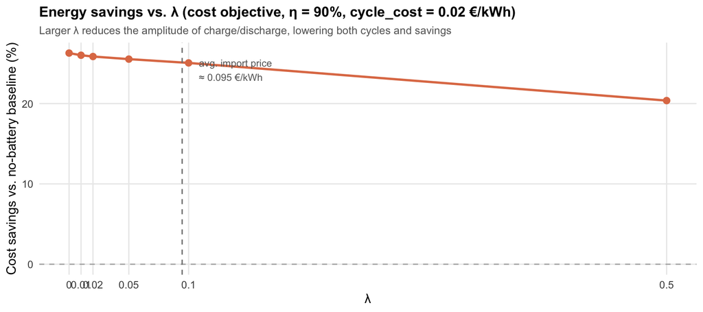

```r
sweep_b_cost_opt_lam_cc02 |>
  mutate(
    cost_savings_pct = (base_battery$cost - cost) /
                        abs(base_battery$cost) * 100
  ) |>
  ggplot(aes(lambda, cost_savings_pct)) +
  geom_hline(yintercept = 0, linetype = "dashed", colour = "grey70") +
  geom_line(linewidth = 1, colour = "#E07B54") +
  geom_point(size = 2.5, colour = "#E07B54") +
  geom_vline(
    xintercept = avg_import_price,
    linetype = "dashed", colour = "grey50"
  ) +
  annotate("text",
    x     = avg_import_price * 1.15,
    y     = max(sweep_b_cost_opt_lam_cc02 |>
                  mutate(s = (base_battery$cost - cost) / abs(base_battery$cost) * 100) |>
                  pull(s)) * 0.92,
    label = paste0("avg. import price\n≈ ", round(avg_import_price, 3), " €/kWh"),
    size  = 3.2, colour = "grey40", hjust = 0
  ) +
  scale_x_continuous(
    breaks = LAMBDA_SEQ,
    labels = as.character(LAMBDA_SEQ)
  ) +
  labs(
    title    = "Energy savings vs. λ (cost objective, η = 90%, cycle_cost = 0.02 €/kWh)",
    subtitle = "Larger λ reduces the amplitude of charge/discharge, lowering both cycles and savings",
    x        = "λ",
    y        = "Cost savings vs. no-battery baseline (%)"
  ) +
  theme_bench()
```

The savings decline as `lambda` increases, consistent with the cycle count reduction: smoother charge/discharge profiles exploit the price spread less aggressively. Setting `lambda` near the average import price still retains most of the energy savings while meaningfully reducing the cycle count — this confirms the λ ≈ average import price recommendation from the previous section.

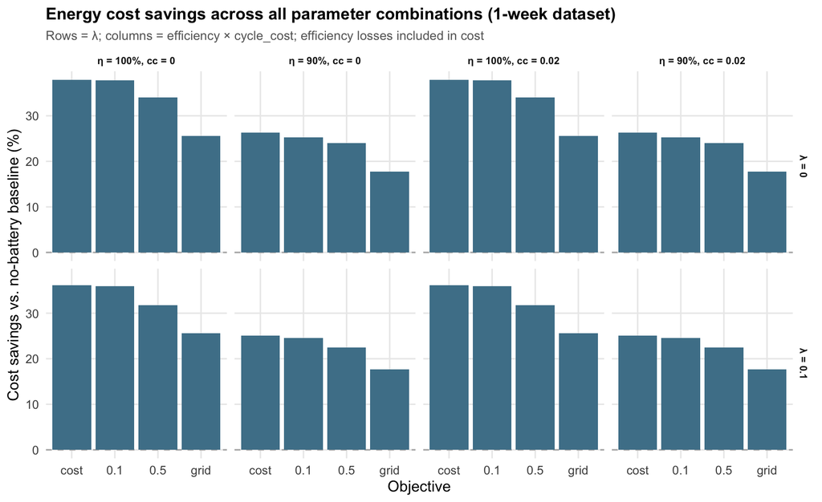

```r
sweep_b_overview |>
  mutate(
    cost_savings_pct = (base_battery$cost - cost) / abs(base_battery$cost) * 100,
    lambda_lab = paste0("λ = ", lambda),
    objective  = factor(objective, levels = c("cost", "0.1", "0.5", "grid")),
    eff_cc_lab = paste0(
      ifelse(eff == 1.0, "η = 100%", "η = 90%"),
      ", cc = ", cycle_cost
    ),
    eff_cc_lab = factor(eff_cc_lab, levels = c(
      "η = 100%, cc = 0", "η = 90%, cc = 0",
      "η = 100%, cc = 0.02", "η = 90%, cc = 0.02"
    ))
  ) |>
  ggplot(aes(objective, cost_savings_pct)) +
  geom_hline(yintercept = 0, linetype = "dashed", colour = "grey70") +
  geom_col(fill = "#4E8098") +
  facet_grid(lambda_lab ~ eff_cc_lab, scales = "fixed") +
  labs(
    title    = "Energy cost savings across all parameter combinations (1-week dataset)",
    subtitle = "Rows = λ; columns = efficiency × cycle_cost; efficiency losses included in cost",
    x        = "Objective",
    y        = "Cost savings vs. no-battery baseline (%)"
  ) +
  theme_bench() +
  theme(strip.text = element_text(size = 8))
```

# 3 · Computation time

> ⚠️ This section runs the timing sweep on the full 1-year dataset (35 040 rows) for λ = 0, 0.01, and 0.1. It may take **10–30 minutes** to complete on first run; results are cached.

```r
objectives <- c("cost", "0.1", "0.5", "grid")
timing_lam_seq <- c(0, 0.01, 0.1)

# ── Demand timing (1-year dataset, λ = 0 / 0.01 / 0.1) ───────────────────────
timing_demand <- purrr::map(timing_lam_seq, function(lam) {
  purrr::map(objectives, function(obj_chr) {
    obj <- if (obj_chr %in% c("grid", "cost")) obj_chr else as.numeric(obj_chr)
    d   <- demand_opt_data(profiles_year) |>
      mutate(price_exported = price_imported - 0.05)
    res <- bench_demand(d, opt_objective = obj, lambda = lam)
    tibble::tibble(
      objective = obj_chr,
      lambda    = lam,
      time_sec  = res$time_sec
    )
  }) |> purrr::list_rbind()
}) |> purrr::list_rbind()

# ── Battery timing (1-year dataset, λ = 0 / 0.01 / 0.1) ─────────────────────
timing_battery <- purrr::map(timing_lam_seq, function(lam) {
  purrr::map(objectives, function(obj_chr) {
    purrr::map(c(1.0, 0.90), function(eff_val) {
      purrr::map(c(0, 0.02), function(cc_val) {
        obj <- if (obj_chr %in% c("grid", "cost")) obj_chr else as.numeric(obj_chr)
        d   <- battery_opt_data(profiles_year) |>
          mutate(price_exported = price_imported - 0.05)
        res <- bench_battery(d, opt_objective = obj, lambda = lam,
                             charge_eff = eff_val, discharge_eff = eff_val,
                             cycle_cost = cc_val,
                             Bcap = BCAP, Bc = BC, Bd = BD)
        tibble::tibble(
          objective  = obj_chr,
          lambda     = lam,
          eff        = eff_val,
          cycle_cost = cc_val,
          time_sec   = res$time_sec
        )
      }) |> purrr::list_rbind()
    }) |> purrr::list_rbind()
  }) |> purrr::list_rbind()
}) |> purrr::list_rbind()
```

## 3.1 · Demand computation time

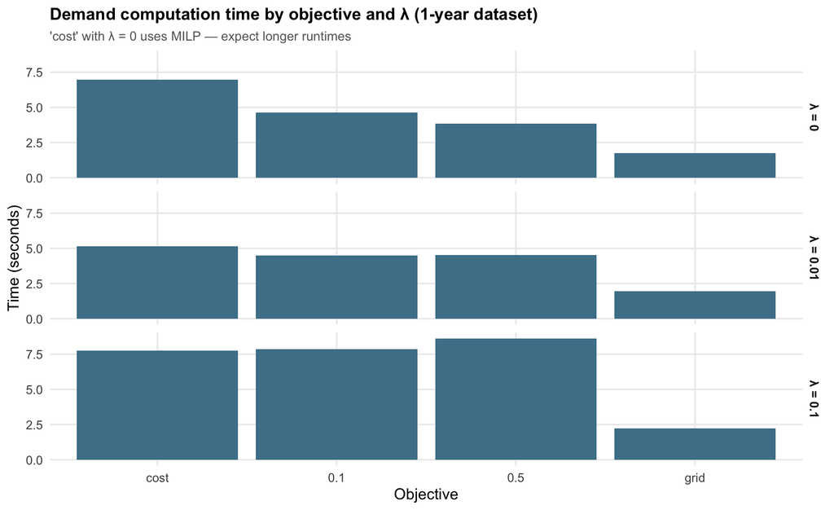

```r
timing_demand |>
  mutate(
    lambda_lab = factor(paste0("λ = ", lambda),
                        levels = paste0("λ = ", timing_lam_seq)),
    objective  = factor(objective, levels = c("cost", "0.1", "0.5", "grid"))
  ) |>
  ggplot(aes(objective, time_sec)) +
  geom_col(fill = "#4E8098") +
  facet_grid(lambda_lab ~ ., scales = "fixed") +
  labs(
    title    = "Demand computation time by objective and λ (1-year dataset)",
    subtitle = "'cost' with λ = 0 uses MILP — expect longer runtimes",
    x        = "Objective",
    y        = "Time (seconds)"
  ) +
  theme_bench()
```

## 3.2 · Battery computation time

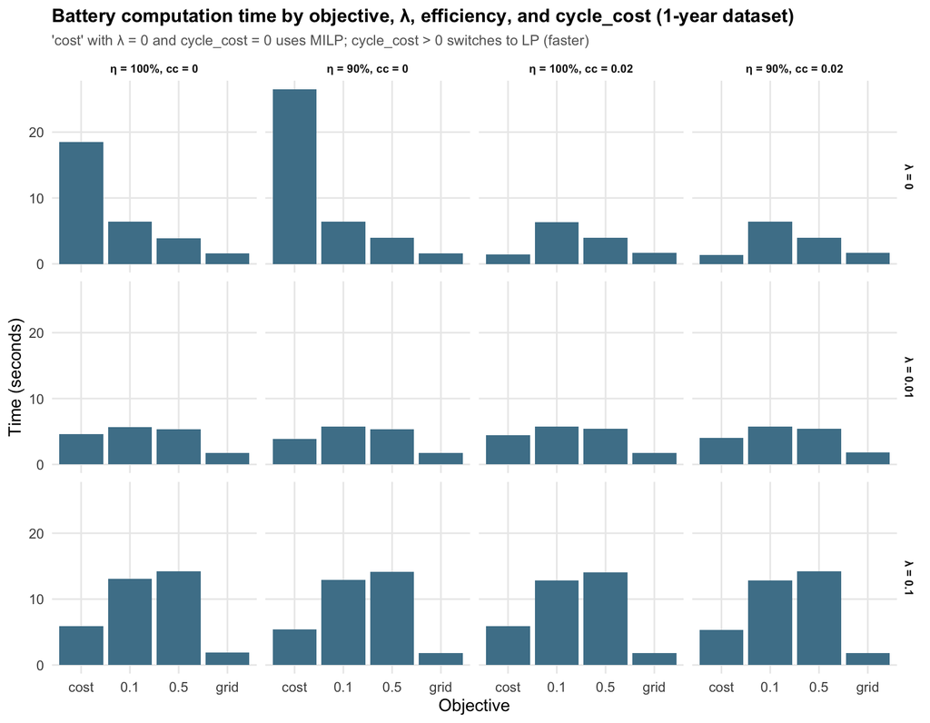

```r
timing_battery |>
  mutate(
    lambda_lab = factor(paste0("λ = ", lambda),
                        levels = paste0("λ = ", timing_lam_seq)),
    objective  = factor(objective, levels = c("cost", "0.1", "0.5", "grid")),
    eff_cc_lab = paste0(
      ifelse(eff == 1.0, "η = 100%", "η = 90%"),
      ", cc = ", cycle_cost
    ),
    eff_cc_lab = factor(eff_cc_lab, levels = c(
      "η = 100%, cc = 0", "η = 90%, cc = 0",
      "η = 100%, cc = 0.02", "η = 90%, cc = 0.02"
    ))
  ) |>
  ggplot(aes(objective, time_sec)) +
  geom_col(fill = "#4E8098") +
  facet_grid(lambda_lab ~ eff_cc_lab, scales = "fixed") +
  labs(
    title    = "Battery computation time by objective, λ, efficiency, and cycle_cost (1-year dataset)",
    subtitle = "'cost' with λ = 0 and cycle_cost = 0 uses MILP; cycle_cost > 0 switches to LP (faster)",
    x        = "Objective",
    y        = "Time (seconds)"
  ) +
  theme_bench() +
  theme(strip.text = element_text(size = 8))
```